# Data aggregation and summarization at scale

Hector Corrada Bravo  
CMSC498T Spring 2015

### For today

1. Project questions
2. Log transform
3. Parallelism, Map-Reduce and Spark

### Transforming Data

Dealing with skewed data

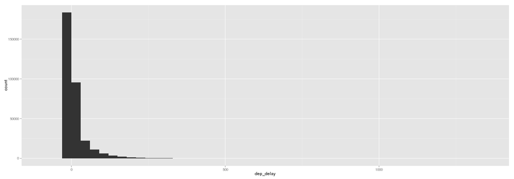

```r
flights %>% ggplot(aes(dep_delay)) + geom_histogram(binwidth=30)
```

### Transforming Data

Dealing with skewed data

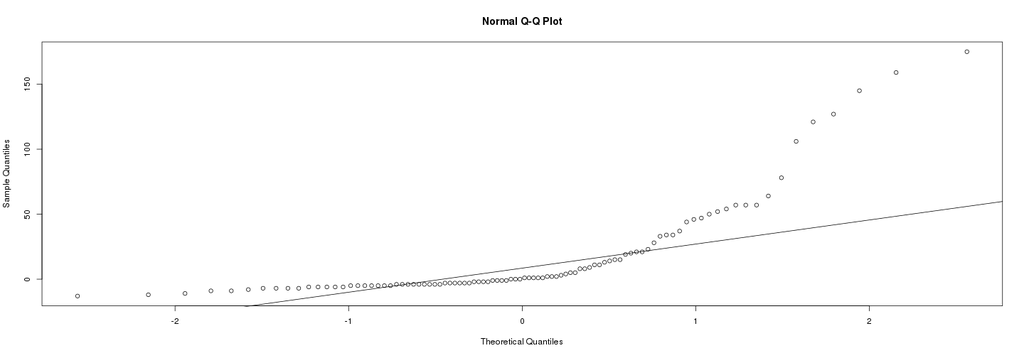

```r
library(magrittr)
flights %>%
  sample_n(100) %>%
  magrittr::extract2("dep_delay") %T>%
  qqnorm %>%
  qqline
```

### Skewed Data

Considerations:

- Long-tail variables hard to incorporate into some modeling procedures, especially in the presence of other variables that are not long-tailed
- Variables may capture *multiplicative* processes: very common in physical and biochemical processes

### Skewed Data

When a multiplicative process makes sense, then a logarithmic transform is appropriate to handle this.

- If values are all positive: apply `log2` transform
- If some values are negative, two options
  - Started Log: shift all values so they are positive, apply `log2`
  - Signed Log: \( sign(x) \times log2(abs(x)) \), but set all \( |x| < 1 \) to \( 1 \).

### Skewed Data

Started log:

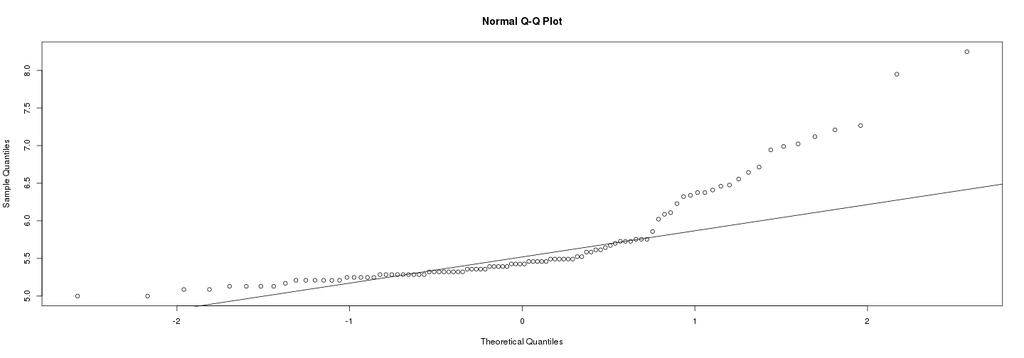

```r
flights %>%
  mutate(log_delay = log2(dep_delay - min(dep_delay, na.rm=TRUE) + 1)) %>%
  sample_n(100) %>%
  magrittr::extract2("log_delay") %T>%
  qqnorm() %>%
  qqline()
```

### Skewed Data

Signed log:

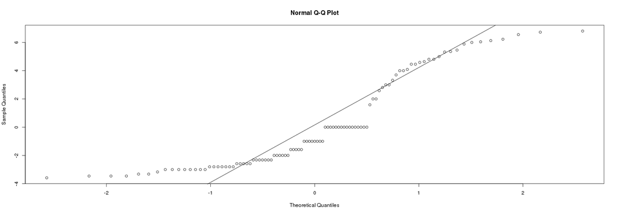

```r
flights %>%
  mutate(log_delay = ifelse(abs(dep_delay) < 1, 0, sign(dep_delay) * log2(abs(dep_delay)))) %>%
  sample_n(100) %>%
  magrittr::extract2("log_delay") %T>%
  qqnorm() %>%
  qqline()
```

### Manipulation and summarization at scale

For very large datasets, many of the operations we've seen for aggregation and summarization can be parallelized:

- partition observations and perform transformation on each partition as a parallel process
- partition variables and perform transformation on each variable as a parallel process
- for summarization (`group_by` and `summarize`), partition observations based on `group_by` expression, perform `summarize` on each partition.

### Manipulation and summarization at scale

Efficiency of implementation of this type of parallelism depends on underlying architecture.

- Shared memory vs. Shared storage vs. Shared nothing
- For massive datasets, last is usually preferred
  - Fault tolerance most important consideration

### Map-reduce

Map-Reduce is an implementation idea for a shared nothing architecture. Main features:

- Distributed storage
- Data proximity (perform operaations on data that is physically close)
- Fault tolerance

### Map-reduce

Basic computation paradigm is based on two operations:

- reduce: perform operation on subset of observations in parallel
- map: decide which parallel process (node) should operate on each observation

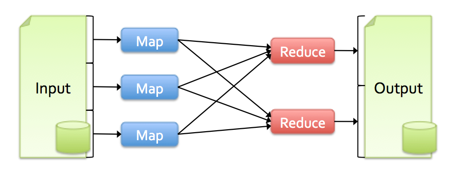

### Map-reduce

Basic computation paradigm is based on two operations:

- reduce: perform operation on subset of observations in parallel
- map: decide which parallel process (node) should operate on each observation

`group_by` clause corresponds to `map`  
`summarize` function corresponds to `reduce`

### Map-reduce

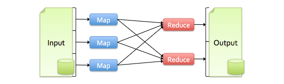

- Most efficient when computations organized in an acyclic graph.
  - Move data from stable storage to computing process
  - Move result to stable storage

### Map-reduce

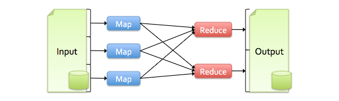

- Runtime benefits:
  - resource allocation
  - failure recovery
- Existing implementations do not support interactive use

### Spark

Recent system, based on general map-reduce framework, for ultra-fast data analysis

Features:

- efficient support for interactive analysis
  - (the kind we do in R)
- designed to support iterative workflows
  - (many Machine Learning algorithms need this)

### Spark

- Basic data abstraction is the RDD (resilient distributed datasets).
- Applications can keep working sets of data in memory
  - iterative algorithms
  - interactive workflows

### Spark

Basic data abstraction is the RDD (resilient distributed datasets).

- Inmutable, *partitioned* collections of objects
- Created by parallel *transformations* on data in stable storage
  - (map, filter, group_by, join, …)
- Can be *cached* for efficient reuse
- Actions on RDDs (count, reduce, collect, save, …)

### Example (using SparkR)

Count occurences of phrases in abstracts (based on regular expression searches) over a large scientific corpus.

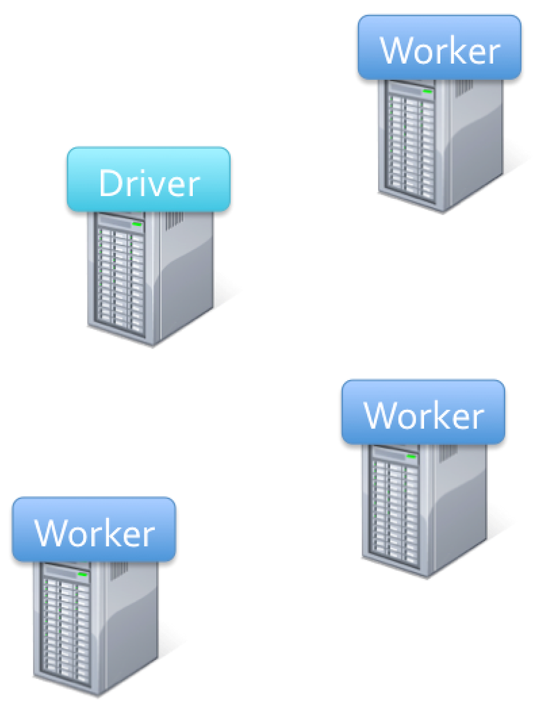